# TO 628 Group 5 Project: Faulty Steel Plates Prediction

Nancy Kim, Stephanie Chan, Shraddha Ramesh, Meng-Ni Ho, Jen Hung

Analyses completed: 2020-04-20

### I. Project Description

In this project, we would like to utilize machine learning techniques to classify types of surface defects in stainless steel plates. There are seven types of defects in the dataset:

- Pastry
- Z_Scratch
- K_Scatch
- Stains
- Dirtiness
- Bumps
- Other_Faults

#### Dataset resource: [here](https://www.kaggle.com/uciml/faulty-steel-plates?fbclid=IwAR1_GKUHnj6D0haU8UuIj24jjeXzXtkwghQAI-y9y_FcXLrOnOIg3W1Kwd8)

### II. Load data + Library

```r
library(tidyverse, quietly = T)
library(naniar, quietly = T)
library(C50, quietly = T)
library(e1071, quietly = T)
library(caret, quietly = T)
library(class, quietly = T)
library(gmodels, quietly = T)
library(neuralnet, quietly = T)
library(nnet, quietly = T)
library(stargazer, quietly = T)
library(knitr, quietly = T)
faults <- read.csv("faults_recode.csv")
```

### III. Data Cleaning and Exploration

```r
faults %>% glimpse()
```

```
## Observations: 1,941
## Variables: 35
## $ X_Minimum             <int> 42, 645, 829, 853, 1289, 430, 413, 190, 330, 74…
## $ X_Maximum             <int> 50, 651, 835, 860, 1306, 441, 446, 200, 343, 90…
## $ Y_Minimum             <int> 270900, 2538079, 1553913, 369370, 498078, 10025…
## $ Y_Maximum             <int> 270944, 2538108, 1553931, 369415, 498335, 10033…
## $ Pixels_Areas          <int> 267, 108, 71, 176, 2409, 630, 9052, 132, 264, 1…
## $ X_Perimeter           <int> 17, 10, 8, 13, 60, 20, 230, 11, 15, 46, 13, 42,…
## $ Y_Perimeter           <int> 44, 30, 19, 45, 260, 87, 432, 20, 26, 167, 48, …
## $ Sum_of_Luminosity     <int> 24220, 11397, 7972, 18996, 246930, 62357, 14819…
## $ Minimum_of_Luminosity <int> 76, 84, 99, 99, 37, 64, 23, 124, 53, 53, 76, 97…
## $ Maximum_of_Luminosity <int> 108, 123, 125, 126, 126, 127, 199, 172, 148, 14…
## $ Length_of_Conveyer    <int> 1687, 1687, 1623, 1353, 1353, 1387, 1687, 1687,…
## $ TypeOfSteel_A300      <int> 1, 1, 1, 0, 0, 0, 0, 0, 0, 0, 0, 0, 0, 0, 0, 0,…
## $ TypeOfSteel_A400      <int> 0, 0, 0, 1, 1, 1, 1, 1, 1, 1, 1, 1, 1, 1, 1, 1,…
```

[output cut: 22 more lines]

2. Checking for missing values:

```r
faults %>% miss_var_summary() #No NAs
```

```
## # A tibble: 35 x 3
##    variable              n_miss pct_miss
##    <chr>                  <int>    <dbl>
##  1 X_Minimum                  0        0
##  2 X_Maximum                  0        0
##  3 Y_Minimum                  0        0
##  4 Y_Maximum                  0        0
##  5 Pixels_Areas               0        0
##  6 X_Perimeter                0        0
##  7 Y_Perimeter                0        0
##  8 Sum_of_Luminosity          0        0
##  9 Minimum_of_Luminosity      0        0
## 10 Maximum_of_Luminosity      0        0
## # … with 25 more rows
```

```r
#any(is.na(faults))
```

There are no missing values in this dataset.

3. Now, let’s take a look at the distribution of each defects, we can see that most defects fall in `Bumps`, `K_Scatch` and `Other_Faults`.

```r
table(faults$label)
```

```
##
##        Bumps    Dirtiness     K_Scatch Other_Faults       Pastry       Stains
##          402           55          391          673          158           72
##    Z_Scratch
##          190
```

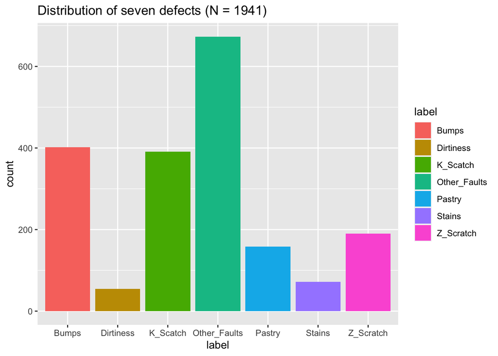

```r
ggplot(data = faults, aes(label, fill = label)) +
  geom_bar() +
  ggtitle("Distribution of seven defects (N = 1941)")
```

4. Create another variable `relabel` indicates the combined version of the seven defects, we combined `Stains` and `Dirtiness` to `Other_Faults`, since `Stains` and `Dirtiness` showed the least freqeuncies among the seven defects. After combinding, we reached to five types of defects: `Pastry`, `Z_Scratch`, `K_Scatch`, `Bumps`, `Other_Faults`.

```r
faults$relabel = ifelse(faults$label == "Pastry", 1,
                        ifelse(faults$label == "Z_Scratch", 2,
                               ifelse(faults$label == "K_Scatch", 3,
                                      ifelse(faults$label == "Bumps", 4,
                                             ifelse(faults$label == "Stains", 5,
                                                    ifelse(faults$label == "Dirtiness",5,
                                                           ifelse(faults$label == "Other_Faults", 5, NA)))))))
faults$relabel = factor(faults$relabel, levels = c(1, 2, 3, 4, 5), labels = c("Pastry", "Z_Scratch", "K_Scatch", "Bumps", "Other_Faults"))

table(faults$relabel)
```

```
##
##       Pastry    Z_Scratch     K_Scatch        Bumps Other_Faults
##          158          190          391          402          800
```

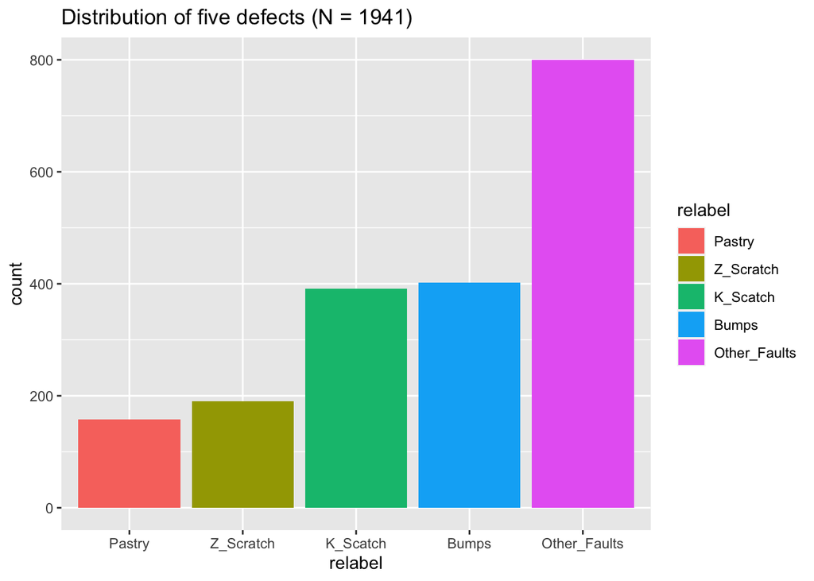

```r
ggplot(data = faults, aes(relabel, fill = relabel)) +
  geom_bar() +
  ggtitle("Distribution of five defects (N = 1941)")
```

5. Below are the box-whisker plots showing distribution of some of our training parameters:

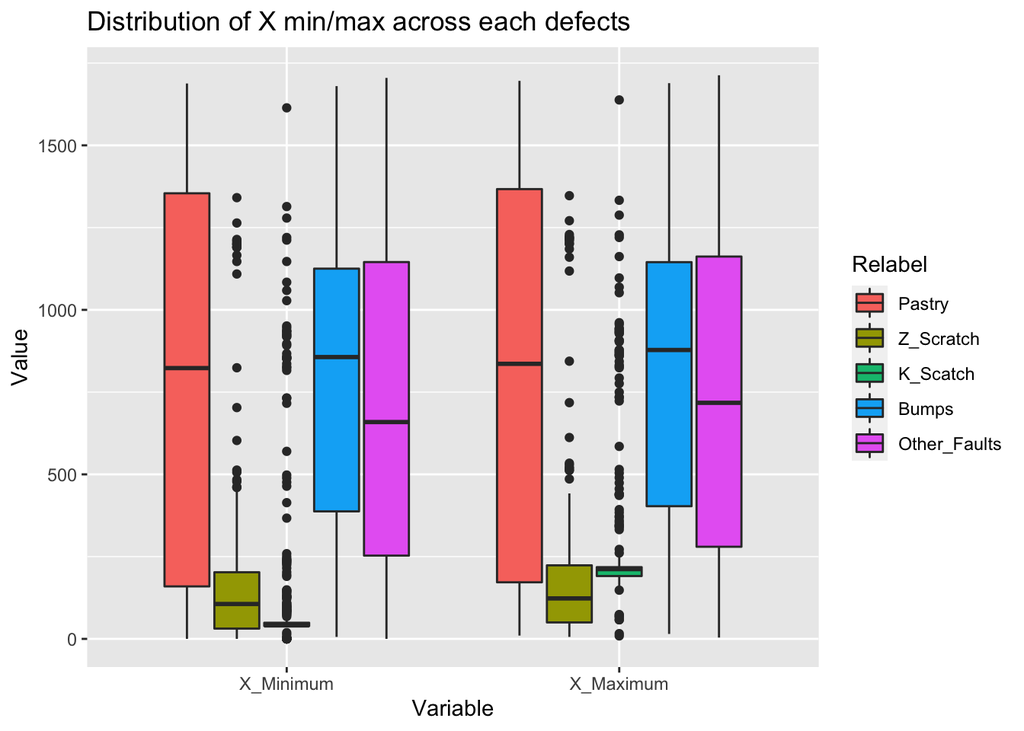

```r
# distribution of X_Minimum, X_Maximum
ggdata_Xmin = cbind(faults[,c("X_Minimum", "relabel")], data.frame(Variable = rep("X_Minimum", 1941)))
colnames(ggdata_Xmin) = c("Value", "Relabel", "Variable")
ggdata_Xmax = cbind(faults[,c("X_Maximum", "relabel")], data.frame(Variable = rep("X_Maximum", 1941)))
colnames(ggdata_Xmax) = c("Value", "Relabel", "Variable")
ggdata_X = rbind(ggdata_Xmin, ggdata_Xmax)

ggplot(data = ggdata_X, aes(x = Variable, y = Value, fill = Relabel)) +
  geom_boxplot() +
  ggtitle("Distribution of X min/max across each defects")
```

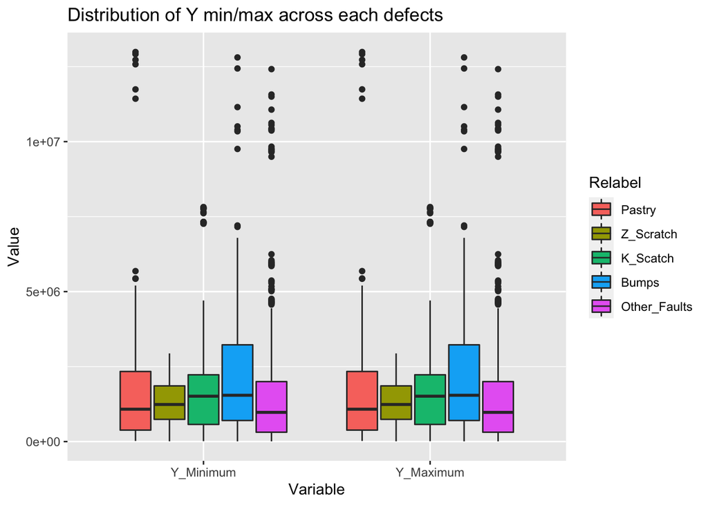

```r
# distribution of Y_Minimum, Y_Maximum
ggdata_Ymin = cbind(faults[,c("Y_Minimum", "relabel")], data.frame(Variable = rep("Y_Minimum", 1941)))
colnames(ggdata_Ymin) = c("Value", "Relabel", "Variable")
ggdata_Ymax = cbind(faults[,c("Y_Maximum", "relabel")], data.frame(Variable = rep("Y_Maximum", 1941)))
colnames(ggdata_Ymax) = c("Value", "Relabel", "Variable")
ggdata_Y = rbind(ggdata_Ymin, ggdata_Ymax)

ggplot(data = ggdata_Y, aes(x = Variable, y = Value, fill = Relabel)) +
  geom_boxplot() +
  ggtitle("Distribution of Y min/max across each defects")
```

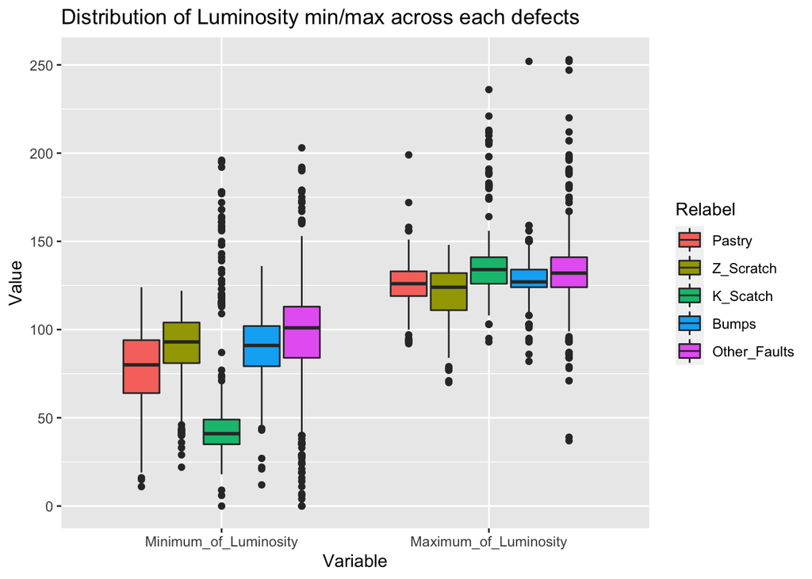

```r
# distribution of Minimum_of_Luminosity, Maximum_of_Luminosity
ggdata_Lummin = cbind(faults[,c("Minimum_of_Luminosity", "relabel")], data.frame(Variable = rep("Minimum_of_Luminosity", 1941)))
colnames(ggdata_Lummin) = c("Value", "Relabel", "Variable")
ggdata_Lummax = cbind(faults[,c("Maximum_of_Luminosity", "relabel")], data.frame(Variable = rep("Maximum_of_Luminosity", 1941)))
colnames(ggdata_Lummax) = c("Value", "Relabel", "Variable")
ggdata_Lum = rbind(ggdata_Lummin, ggdata_Lummax)

ggplot(data = ggdata_Lum, aes(x = Variable, y = Value, fill = Relabel)) +
  geom_boxplot() +
  ggtitle("Distribution of Luminosity min/max across each defects")
```

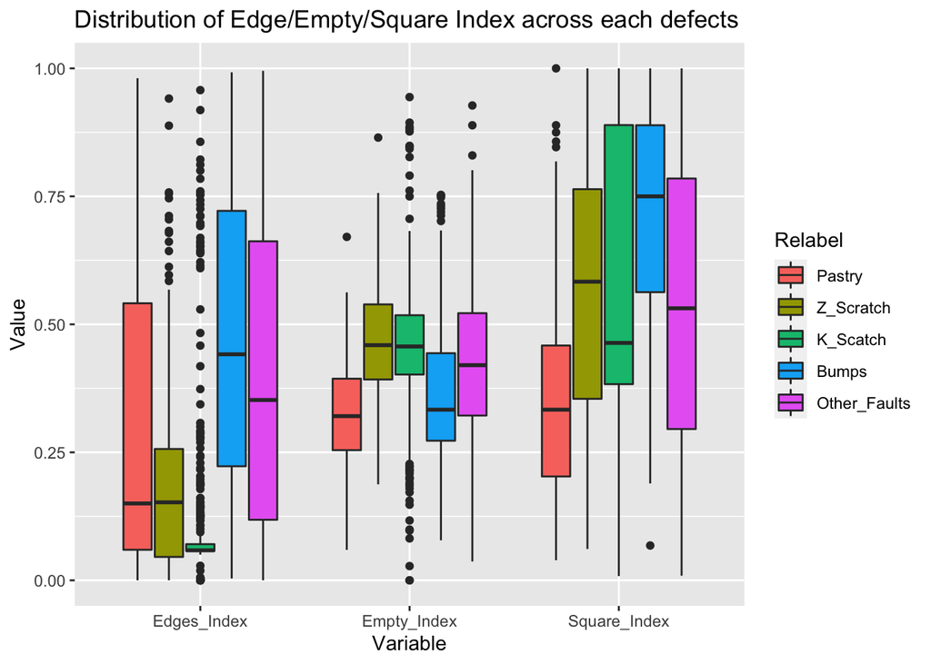

```r
# distribution of Edges_Index, Empty_Index, Square_Index
ggdata_edge = cbind(faults[,c("Edges_Index", "relabel")], data.frame(Variable = rep("Edges_Index", 1941)))
colnames(ggdata_edge) = c("Value", "Relabel", "Variable")
ggdata_empty = cbind(faults[,c("Empty_Index", "relabel")], data.frame(Variable = rep("Empty_Index", 1941)))
colnames(ggdata_empty) = c("Value", "Relabel", "Variable")
ggdata_square = cbind(faults[,c("Square_Index", "relabel")], data.frame(Variable = rep("Square_Index", 1941)))
colnames(ggdata_square) = c("Value", "Relabel", "Variable")

ggdata_idx = rbind(ggdata_edge, ggdata_empty, ggdata_square)

ggplot(data = ggdata_idx, aes(x = Variable, y = Value, fill = Relabel)) +
  geom_boxplot() +
  ggtitle("Distribution of Edge/Empty/Square Index across each defects")
```

6. Recoding of type of steel, type of steel is either “A300” (`TypeOfSteel_A300`) or “A400” (`TypeOfSteel_A400`), in here, we combine these two variables to an indicator `SteelType`, indicates 1 for A300, 0 for A400.

```r
#Type of steel is merged into a single column and mase to factor
faults$SteelType<-ifelse(faults$TypeOfSteel_A300==1,1,0)
#faults$SteelType<-as.factor(faults$SteelType)
```

7. Select the variables used for training, note that `Pastry`, `Z_Scratch`, `K_Scatch`, `Stains`, `Dirtiness`, `Bumps`, `Other_Faults` are the indicators for seven types of defects, which are now combined into `relabel`. `Relabel` will be set as our training outcome.

```r
# select relevant variables
# outcome: sdata$label
new.faults = faults %>% dplyr::select(-c(Pastry, Z_Scratch, K_Scatch, Stains, Dirtiness, Bumps, Other_Faults, TypeOfSteel_A300, TypeOfSteel_A400, label))
```

`new.faults` is our final cleaned data that will be used for machine learning training.

### IV. Split training and testing set: ratio 7:3

training set: N = 1358  
testing set: N = 583

```r
# split train and test dataset
set.seed(40)
train_ind <- sample(seq_len(nrow(new.faults)), size = as.integer(dim(new.faults)[1]*0.7))

train <- new.faults[train_ind,]
test <- new.faults[-train_ind,]
```

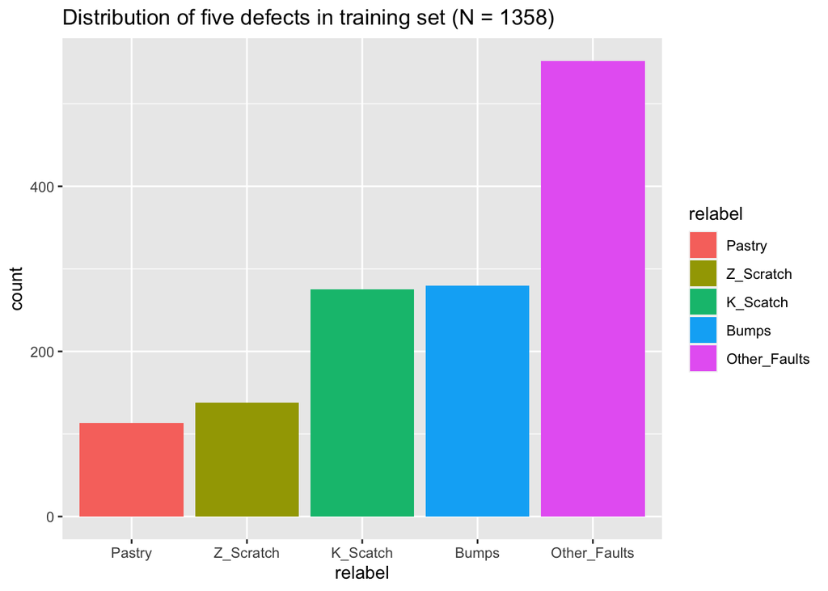

```r
ggplot(data = train, aes(relabel, fill = relabel)) +
  geom_bar() +
  ggtitle("Distribution of five defects in training set (N = 1358)")
```

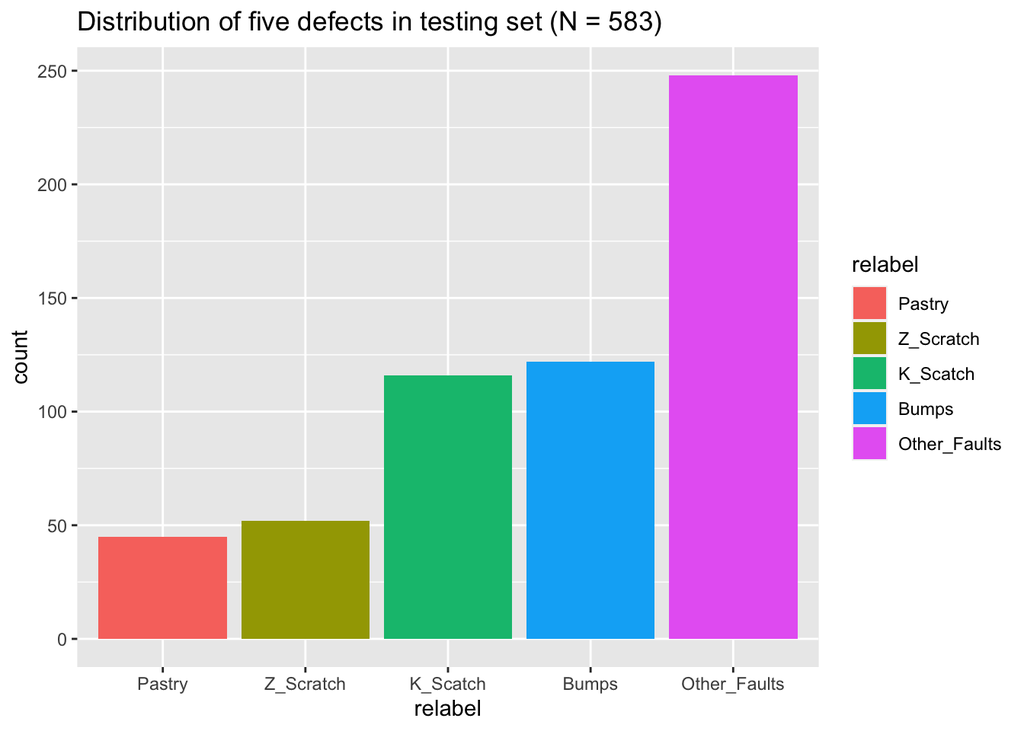

```r
ggplot(data = test, aes(relabel, fill = relabel)) +
  geom_bar() +
  ggtitle("Distribution of five defects in testing set (N = 583)")
```

### V. Model training and testing

#### Model 1: Multinomial Logistic Regression

```r
# NNET-> Multinom
system.time({
  multinom_1<- multinom(relabel ~.,data= train)
})
```

```
##    user  system elapsed
##   0.263   0.004   0.280
```

```r
# summary(multinom_1)
#Model-18
system.time({
multinom_18 <- multinom(as.factor(relabel)~Steel_Plate_Thickness+Outside_X_Index+LogOfAreas+Log_X_Index+Length_of_Conveyer+Maximum_of_Luminosity+Edges_Index+SteelType+Log_Y_Index+X_Minimum+Y_Minimum+Square_Index+Orientation_Index+Pixels_Areas+Luminosity_Index+X_Maximum+Y_Maximum+Minimum_of_Luminosity+Y_Perimeter, data = train)
})
```

```
##    user  system elapsed
##   0.195   0.004   0.222
```

```r
#summary(multinom_18) #AIC: 2196.181

#confusionMatrix(multinom_18_pred,fault_test$label)
#  Accuracy : 0.7307

# to get pvalues
# stargazer(multinom_1, type="text", out="multi1.txt")
stargazer(multinom_18, type="text", out="multi1.txt")
```

```
##
## ===================================================================
##                                    Dependent variable:
##                       ---------------------------------------------
##                       Z_Scratch   K_Scatch    Bumps    Other_Faults
##                          (1)        (2)        (3)         (4)
## -------------------------------------------------------------------
## Steel_Plate_Thickness -0.007***  -0.271***  -0.004***    0.003***
##                       (0.00000)  (0.00000)  (0.00000)   (0.00000)
##
## Outside_X_Index        0.736***  -0.329***  -4.280***   -0.762***
##                        (0.000)    (0.000)    (0.000)     (0.000)
##
## LogOfAreas            -3.268***   5.618***  -2.916***   -5.937***
##                       (0.00000)  (0.00000)  (0.00000)   (0.00000)
##
## Log_X_Index           -3.261***  -19.825*** -3.887***   -3.223***
##                       (0.00000)  (0.00000)  (0.00000)   (0.00000)
##
## Length_of_Conveyer    -0.026***  -0.008***  -0.005***   -0.005***
##                       (0.00002)  (0.00003)   (0.0001)    (0.0001)
##
## Maximum_of_Luminosity -0.183***  -0.014***  -0.038***   -0.052***
##                       (0.00000)  (0.00000)  (0.00001)   (0.00001)
##
## Edges_Index           -1.823***  -1.406***   1.101***    0.296***
##                        (0.000)    (0.000)   (0.00000)   (0.00000)
##
## SteelType              5.242***   0.066***   1.703***    0.217***
##                        (0.000)    (0.000)   (0.00000)   (0.00000)
##
## Log_Y_Index           16.808***  15.687***  16.754***   16.776***
##                       (0.00000)  (0.00000)  (0.00000)   (0.00000)
##
## X_Minimum             -0.092***  -0.153***  -0.107***   -0.139***
##                       (0.00001)  (0.00001)  (0.00005)    (0.0001)
##
## Y_Minimum              0.105***   0.154***   0.179***    0.111***
##                       (0.00000)  (0.00000)  (0.00000)   (0.00000)
##
```

[output cut: 16 more lines]

```
##                       (0.00000)  (0.00000)  (0.00000)   (0.00000)
##
## Minimum_of_Luminosity  0.181***   0.021***   0.052***    0.051***
##                       (0.00000)  (0.00000)  (0.00000)   (0.00001)
##
## Y_Perimeter            0.096***   0.106***   0.100***    0.081***
##                       (0.00000)  (0.00000)  (0.00000)   (0.00000)
##
## Constant              34.498***  18.263***   1.826***    9.301***
##                       (0.00000)  (0.00000)  (0.00000)   (0.00000)
##
## -------------------------------------------------------------------
## Akaike Inf. Crit.     1,821.312  1,821.312  1,821.312   1,821.312
## ===================================================================
## Note:                                   *p<0.1; **p<0.05; ***p<0.01
```

```r
# predict test result
# multinom_1_pred<-predict(multinom_1, test %>% select(-c(relabel)))
multinom_18_pred<-predict(multinom_18,test %>% select(-c(relabel)))
# CrossTable(multinom_1_pred, test$label)
#Accuracy
# sum(multinom_1_pred==fault_test$label)/nrow(fault_test)*100

# confusion matrix
cm.multinom <- confusionMatrix(multinom_18_pred, as.factor(test[, "relabel"]))
accuracy.multinom <- round(as.numeric(cm.multinom$overall[1])*100, digits = 2)
kappa.multinom <- round(as.numeric(cm.multinom$overall[2]), digits = 2)
pred.table.multinom <- cm.multinom$table
print(pred.table.multinom)
```

```
##               Reference
## Prediction     Pastry Z_Scratch K_Scatch Bumps Other_Faults
##   Pastry           23         1        1     1           14
##   Z_Scratch         1        46        0     2           13
##   K_Scatch          0         0      109     1            5
##   Bumps             3         1        2    78           36
##   Other_Faults     18         4        4    40          180
```

```r
#other models considered:
#model-2
#multinom_2<-multinom(as.factor(relabel)~Steel_Plate_Thickness+Outside_X_Index+LogOfAreas+Log_X_Index+Length_of_Conveyer+Maximum_of_Luminosity+Edges_Index+SteelType+Log_Y_Index+X_Minimum,data= train)

#model-3
#multinom_3<-multinom(as.factor(relabel)~Steel_Plate_Thickness+Outside_X_Index+LogOfAreas+Log_X_Index+Length_of_Conveyer+Maximum_of_Luminosity+Edges_Index+SteelType+Log_Y_Index+X_Minimum+Y_Minimum,data= train)


#model-4
#multinom_4<-multinom(as.factor(relabel)~Steel_Plate_Thickness+Outside_X_Index+LogOfAreas+Log_X_Index+Length_of_Conveyer+Maximum_of_Luminosity+Edges_Index+SteelType+Log_Y_Index+X_Minimum+Y_Minimum+X_Minimum*LogOfAreas,data= train)

#Model-5
#multinom_5<-multinom(as.factor(relabel)~Steel_Plate_Thickness+Outside_X_Index+LogOfAreas+Log_X_Index+Length_of_Conveyer+Maximum_of_Luminosity+Edges_Index+SteelType+Log_Y_Index+X_Minimum+Y_Minimum+X_Minimum*LogOfAreas+Steel_Plate_Thickness*LogOfAreas,data= train)

#Model-6
#multinom_6<-multinom(as.factor(relabel)~Steel_Plate_Thickness+Outside_X_Index+LogOfAreas+Log_X_Index+Length_of_Conveyer+Maximum_of_Luminosity+Edges_Index+SteelType+Log_Y_Index+X_Minimum+Y_Minimum+X_Minimum*LogOfAreas+Steel_Plate_Thickness*LogOfAreas+Length_of_Conveyer*LogOfAreas,data= train)

#Model-7
#multinom_7<-multinom(as.factor(relabel)~Steel_Plate_Thickness+Outside_X_Index+LogOfAreas+Log_X_Index+Length_of_Conveyer+Maximum_of_Luminosity+Edges_Index+SteelType+Log_Y_Index+X_Minimum+Y_Minimum+Square_Index,data= train)


#Model-8
#multinom_8<-multinom(as.factor(relabel)~Steel_Plate_Thickness+Outside_X_Index+LogOfAreas+Log_X_Index+Length_of_Conveyer+Maximum_of_Luminosity+Edges_Index+SteelType+Log_Y_Index+X_Minimum+Y_Minimum+Square_Index+Orientation_Index,data= train)


#Model-9
#multinom_9<-multinom(as.factor(relabel)~Steel_Plate_Thickness+Outside_X_Index+LogOfAreas+Log_X_Index+Length_of_Conveyer+Maximum_of_Luminosity+Edges_Index+SteelType+Log_Y_Index+X_Minimum+Y_Minimum+Square_Index+Orientation_Index+SigmoidOfAreas,data= train)

#Model-10
#multinom_10<-multinom(as.factor(relabel)~Steel_Plate_Thickness+Outside_X_Index+LogOfAreas+Log_X_Index+Length_of_Conveyer+Maximum_of_Luminosity+Edges_Index+SteelType+Log_Y_Index+X_Minimum+Y_Minimum+Square_Index+Orientation_Index+Empty_Index,data= train)

#Model-11
#multinom_11<-multinom(as.factor(relabel)~Steel_Plate_Thickness+Outside_X_Index+LogOfAreas+Log_X_Index+Length_of_Conveyer+Maximum_of_Luminosity+Edges_Index+SteelType+Log_Y_Index+X_Minimum+Y_Minimum+Square_Index+Orientation_Index+Pixels_Areas,data= train)

#Model-12
#multinom_12<-multinom(as.factor(relabel)~Steel_Plate_Thickness+Outside_X_Index+LogOfAreas+Log_X_Index+Length_of_Conveyer+Maximum_of_Luminosity+Edges_Index+SteelType+Log_Y_Index+X_Minimum+Y_Minimum+Square_Index+Orientation_Index+Pixels_Areas+Luminosity_Index,data= train)

#Model-13
#multinom_13<-multinom(as.factor(relabel)~Steel_Plate_Thickness+Outside_X_Index+LogOfAreas+Log_X_Index+Length_of_Conveyer+Maximum_of_Luminosity+Edges_Index+SteelType+Log_Y_Index+X_Minimum+Y_Minimum+Square_Index+Orientation_Index+Pixels_Areas+Luminosity_Index+X_Maximum,data= train)

#Model-14
#multinom_14<-multinom(as.factor(relabel)~Steel_Plate_Thickness+Outside_X_Index+LogOfAreas+Log_X_Index+Length_of_Conveyer+Maximum_of_Luminosity+Edges_Index+SteelType+Log_Y_Index+X_Minimum+Y_Minimum+Square_Index+Orientation_Index+Pixels_Areas+Luminosity_Index+X_Maximum+X_Minimum*X_Maximum,data= train)

#Model-15
#multinom_15<-multinom(as.factor(relabel)~Steel_Plate_Thickness+Outside_X_Index+LogOfAreas+Log_X_Index+Length_of_Conveyer+Maximum_of_Luminosity+Edges_Index+SteelType+Log_Y_Index+X_Minimum+Y_Minimum+Square_Index+Orientation_Index+Pixels_Areas+Luminosity_Index+X_Maximum+X_Minimum*X_Maximum+Y_Maximum,data= train)

#Model-16
#multinom_16<-multinom(as.factor(relabel)~Steel_Plate_Thickness+Outside_X_Index+LogOfAreas+Log_X_Index+Length_of_Conveyer+Maximum_of_Luminosity+Edges_Index+SteelType+Log_Y_Index+X_Minimum+Y_Minimum+Square_Index+Orientation_Index+Pixels_Areas+Luminosity_Index+X_Maximum+X_Minimum*X_Maximum+Y_Maximum+Pixels_Areas,data= train)

#Model-17(Remove interaction +X_Minimum*X_Maximum)
#multinom_17<-multinom(as.factor(relabel)~Steel_Plate_Thickness+Outside_X_Index+LogOfAreas+Log_X_Index+Length_of_Conveyer+Maximum_of_Luminosity+Edges_Index+SteelType+Log_Y_Index+X_Minimum+Y_Minimum+Square_Index+Orientation_Index+Pixels_Areas+Luminosity_Index+X_Maximum+Y_Maximum+Minimum_of_Luminosity,data= train)
```

Results: Accuracy of using multinomial logistic regression is 74.79%. Kappa statistics shows 0.65.

#### Model 2: Support Vector Machine:

##### 1. Linear Kernal

```r
# start training using linear kernal
system.time({
  svm.linear <- svm(formula = relabel ~ .,
                 data = train,
                 type = 'C-classification',
                 kernel = 'linear')
})
```

```
##    user  system elapsed
##   0.186   0.004   0.196
```

```r
# predict test result
svm.linear.pred <- predict(svm.linear, newdata = test %>% dplyr::select(-relabel))

# confusion matrix
cm.svm.linear <- confusionMatrix(svm.linear.pred, as.factor(test[, "relabel"]))
accuracy.svm.linear <- round(as.numeric(cm.svm.linear$overall[1])*100, digits = 2)
kappa.svm.linear <- round(as.numeric(cm.svm.linear$overall[2]), digits = 2)
pred.table.svm.linear <- cm.svm.linear$table
print(pred.table.svm.linear)
```

```
##               Reference
## Prediction     Pastry Z_Scratch K_Scatch Bumps Other_Faults
##   Pastry           22         0        0     0           11
##   Z_Scratch         1        43        0     0           10
##   K_Scatch          0         0      106     1            1
##   Bumps             6         0        1    79           43
##   Other_Faults     16         9        9    42          183
```

Results: Accuracy of using SVM linear kernal is 74.27%. Kappa statistics shows 0.64.

##### 2. Radial Kernal

```r
system.time({
  svm.radial <- svm(formula = relabel ~ .,
                 data = train,
                 type = 'C-classification',
                 kernel = 'radial')
})
```

```
##    user  system elapsed
##   0.195   0.004   0.204
```

```r
# predict test result
svm.radial.pred <- predict(svm.radial, newdata = test %>% dplyr::select(-relabel))

# confusion matrix
cm.svm.radial <- confusionMatrix(svm.radial.pred, as.factor(test[, "relabel"]))
accuracy.svm.radial <- round(as.numeric(cm.svm.radial$overall[1])*100, digits = 2)
kappa.svm.radial <- round(as.numeric(cm.svm.radial$overall[2]), digits = 2)
pred.table.svm.radial <- cm.svm.radial$table
print(pred.table.svm.radial)
```

```
##               Reference
## Prediction     Pastry Z_Scratch K_Scatch Bumps Other_Faults
##   Pastry           26         0        0     0            4
##   Z_Scratch         0        44        0     1            8
##   K_Scatch          0         0      108     0            3
##   Bumps             6         1        0    89           39
##   Other_Faults     13         7        8    32          194
```

Results: Accuracy of using SVM radial kernel is 79.07%. Kappa statistics shows 0.71.

#### Model 3: k-Nearest-Neighbors (KNN)

##### 1. Find the best k

We test k from 1 to 20, and find the k with the highest accuracy to perform KNN:

```r
# seperate the variables and labels for train and test dataset

train_label <- train[,"relabel"]
train_KNN <- train %>% select(-relabel)
test_label <- test[,"relabel"]
test_KNN <- test %>% select(-relabel)


#do the z-Score Standardization for dataset
standardized.train_KNN <- scale(train_KNN)
standardized.test_KNN <- scale(test_KNN)

# find the best k-value
accuracy.rate = NULL
for(i in 1:20){
    KNN_pred_find = knn(train = standardized.train_KNN, test = standardized.test_KNN, cl = train_label, k=i)
    accuracy.rate[i] = 1-(mean(test_label != KNN_pred_find))
}
print(accuracy.rate)
```

```
##  [1] 0.7358491 0.7135506 0.7444254 0.7598628 0.7564322 0.7735849 0.7581475
##  [8] 0.7547170 0.7598628 0.7495712 0.7375643 0.7392796 0.7427101 0.7461407
## [15] 0.7392796 0.7375643 0.7392796 0.7444254 0.7307033 0.7221269
```

```r
# find the k with highest accuracy
best_k = which(accuracy.rate == max(accuracy.rate))
print(best_k)
```

```
## [1] 6
```

Therefore, the best k among 1 to 20 is 6, which shows highest accuracy.

##### 2. Build the model with best k:

```r
# use the best k to train
system.time({
  KNN_pred <- knn(train = standardized.train_KNN, test = standardized.test_KNN, cl = train_label, k= best_k)
})
```

```
##    user  system elapsed
##   0.019   0.000   0.020
```

```r
# Accuracy
# accuracy.knn = round(mean(test_label== KNN_pred)*100, digits = 2)

# confusion matrix
cm.knn <- confusionMatrix(KNN_pred, as.factor(test[, "relabel"]))
accuracy.knn <- round(as.numeric(cm.knn$overall[1])*100, digits = 2)
kappa.knn <- round(as.numeric(cm.knn$overall[2]), digits = 2)
pred.table.knn <- cm.knn$table
print(pred.table.knn)
```

```
##               Reference
## Prediction     Pastry Z_Scratch K_Scatch Bumps Other_Faults
##   Pastry           26         2        0     8            7
##   Z_Scratch         0        45        1     5           13
##   K_Scatch          0         0      111     0            6
##   Bumps             6         1        3    87           45
##   Other_Faults     13         4        1    22          177
```

Results: Accuracy of using kNN with k = 6 shows 76.5%. Kappa statistics shows 0.68.

#### Model 4: Decision Tree

##### 1. Find the best boosting trials:

We test boosting trial from 1 to 20, and find the boosting trials with the highest accuracy to perform decision tree:

```r
# find the best boosting trials
accuracy.rate = NULL
for(i in 1:20){
    ds.tree.find <- C5.0(train %>% select(-relabel) , train$relabel, trials = i)
    ds.find.pred <- predict(ds.tree.find, test %>% select(-relabel))
    cm.ds.tree.find <- confusionMatrix(ds.find.pred, as.factor(test[, "relabel"]))
    accuracy.cm.find <- round(as.numeric(cm.ds.tree.find$overall[1])*100, digits = 2)
    accuracy.rate[i] = accuracy.cm.find
}
print(accuracy.rate)
```

```
##  [1] 75.13 75.13 77.02 80.27 82.33 81.30 80.79 80.96 81.30 81.48 81.65 81.82
## [13] 82.50 82.33 82.33 81.30 82.68 82.68 82.68 82.68
```

```r
# find the best boosting trial with highest accuracy
best_t = min(which(accuracy.rate == max(accuracy.rate)))
print(best_t)
```

```
## [1] 17
```

Therefore, the best boosting trial is 17, which shows highest accuracy.

##### 2. Build the model with best boosting trials:

Now, we trained the model with the best boosting trials found in the previous step.

```r
#improve accuracy or reliability (give cost matrix dpending on if false positive or false negative is better)
system.time({
  ds.tree.boost <- C5.0(train %>% dplyr::select(-relabel), train$relabel, trials = best_t)
})
```

```
##    user  system elapsed
##   0.693   0.007   0.708
```

```r
print(ds.tree.boost)
```

```
##
## Call:
## C5.0.default(x = train %>% dplyr::select(-relabel), y = train$relabel, trials
##  = best_t)
##
## Classification Tree
## Number of samples: 1358
## Number of predictors: 26
##
## Number of boosting iterations: 17
## Average tree size: 115.4
##
## Non-standard options: attempt to group attributes
```

```r
# summary(ds.tree.boost)
#CrossTable(test$label, ds.tree.boost12.pred, prop.chisq = FALSE, prop.c = FALSE, prop.r = FALSE, dnn = c('actual label', 'label predictions'))

ds.tree.boost.pred <- predict(ds.tree.boost, test %>% select(-relabel))
cm.ds.tree <- confusionMatrix(ds.tree.boost.pred, as.factor(test[, "relabel"]))
accuracy.cm.ds.tree <- round(as.numeric(cm.ds.tree$overall[1])*100, digits = 2)
kappa.cm.ds.tree <- round(as.numeric(cm.ds.tree$overall[2]), digits = 2)
pred.table.ds.tree <- cm.ds.tree$table
print(pred.table.ds.tree)
```

```
##               Reference
## Prediction     Pastry Z_Scratch K_Scatch Bumps Other_Faults
##   Pastry           22         0        0     5            8
##   Z_Scratch         0        50        0     0            3
##   K_Scatch          0         0      114     1            3
##   Bumps             7         1        0    88           26
##   Other_Faults     16         1        2    28          208
```

Result for summary of the decision tree model:  
Attribute usage:

```
100.00% Length_of_Conveyer
100.00% Steel_Plate_Thickness
100.00% Outside_X_Index
100.00% LogOfAreas
100.00% Log_X_Index
 99.93% Orientation_Index
 99.26% Luminosity_Index
 99.19% Maximum_of_Luminosity
 98.38% Minimum_of_Luminosity
 97.94% X_Maximum
 97.79% Log_Y_Index
 97.20% SteelType
 96.24% Edges_Index
 94.04% Y_Minimum
 93.96% Empty_Index
 91.97% X_Minimum
 85.35% Square_Index
 83.36% Edges_Y_Index
 82.62% Sum_of_Luminosity
 81.96% Edges_X_Index
 81.15% Pixels_Areas
 79.01% X_Perimeter
 75.33% Y_Perimeter
 54.42% Y_Maximum
 42.19% SigmoidOfAreas
 40.65% Outside_Global_Index
```

Results: Accuracy of using decision tree with 17 boosting trials is 82.68%. Kappa statistics shows 0.76.

#### Model 5: Artifical Neural Network (ANN)

```r
# change the data type for label to numeric type
#train_ANN <- train
#train_ANN <- train_ANN[,-26]
#test_ANN <- test_ANN[,-26]

#do the z-Score Standardization for dataset
standardized.train_ANN <- scale(train %>% dplyr::select(-relabel))
standardized.test_ANN <- scale(test %>% dplyr::select(-relabel))

# merge label back to train/test data
standardized.train_ANN <- as.data.frame(cbind(standardized.train_ANN, train$relabel))
colnames(standardized.train_ANN)[dim(standardized.train_ANN)[2]] <- "relabel"
standardized.test_ANN <- as.data.frame(cbind(standardized.test_ANN, test$relabel))
colnames(standardized.test_ANN)[dim(standardized.test_ANN)[2]] <- "relabel"

# ANN modeling
system.time({
  ANN_model <- neuralnet(formula = as.factor(relabel) ~ .,
                       data = standardized.train_ANN,
                       hidden = 4)
})
```

```
##    user  system elapsed
##  35.961   7.778  45.102
```

```r
# plot(ANN_model)

# obtain model results
test_results <- predict(ANN_model, standardized.test_ANN %>% select(-relabel))
# obtain predicted
#predicted_label <- test_results$net.result
#table(standardized.test_ANN[,"label_num"], apply(test_results, 1, which.max))

# examine the correlation between predicted and actual values
#cor(predicted_label, standardized.test_ANN[,"label_num"])

cm.ann <- confusionMatrix(as.factor(apply(test_results, 1, which.max)), as.factor(standardized.test_ANN[, "relabel"]))

accuracy.cm.ann <- round(as.numeric(cm.ann$overall[1])*100, digits = 2)
kappa.cm.ann <- round(as.numeric(cm.ann$overall[2]), digits = 2)
pred.table.ann <- cm.ann$table
print(pred.table.ann)
```

```
##           Reference
## Prediction   1   2   3   4   5
##          1  14   0   0   1   5
##          2   0  36   0   1   7
##          3   3   1 108   1  10
##          4   4   0   1  65  31
##          5  24  15   7  54 195
```

Plotting the ANN model:

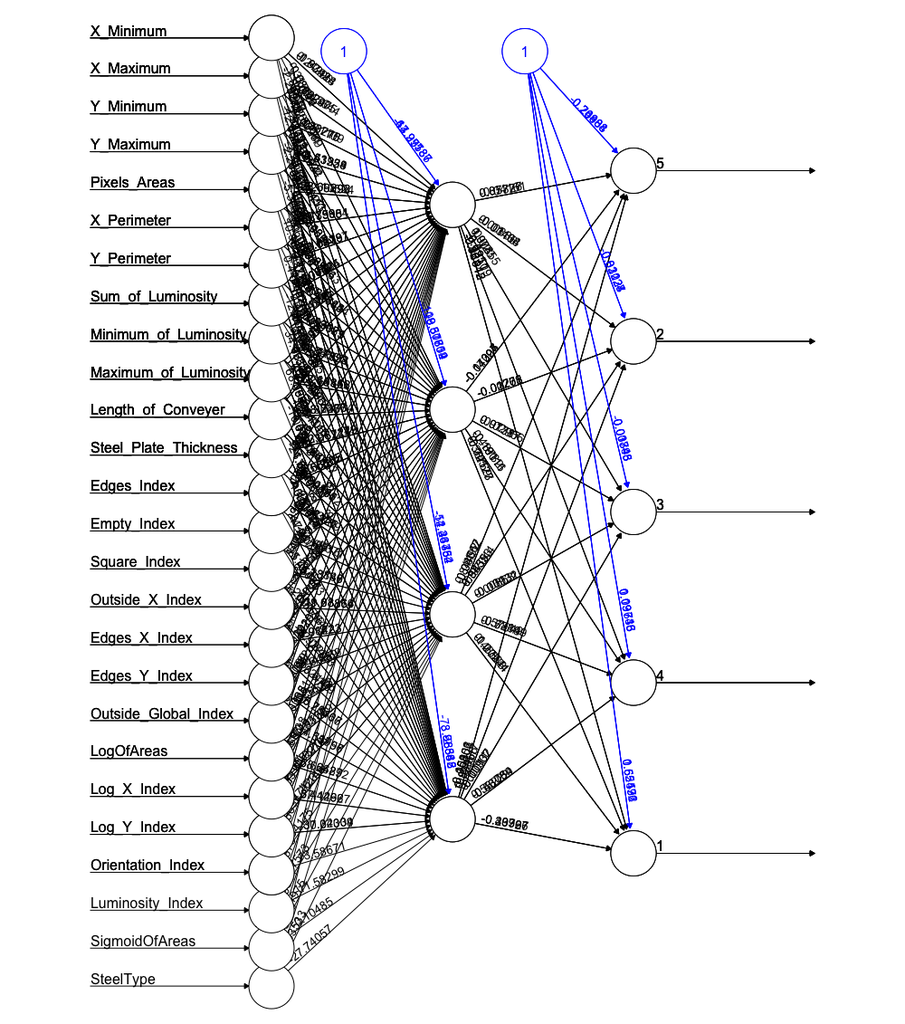

Results: Accuracy of using ANN 1 hidden layers with 4 nodes is 71.7%. Kappa statistics shows 0.59.

### VI. Comparing Accuracy

The below tables show the accuracy of the above five methods:

[output not shown]

### VII. Application & Conclusion

Our dataset and model together answer the question, what kind of defect does a steel plate has, which is simple, but has a lot of business implications. Steel is mostly used in construction, “accounting for more than 50% of world steel demand”. [2] To reduce risk for safety, environmental impact, and economic loss, fault detection becomes really important in the manufacutring processes. In the manufacturing industry this is called “Fault Diagnosis (FD)” [1] and “has a major importance to enhance the quality of manufacutring and to lessen the cost of product testing.” [1] For this project, the team developed several ML models that would help detect the types of faults as early as possible and prevent serious issues from occurring.

The decision tree model with boosting trials the team developed and selected to be the best among the models tested can provide useful business applications for manufacturers. This model will help the faults to be detected and identified as early as possible to help the manufacturers employ proper precautionary measures early on. In addition, “during manufacturing downtimes, most of the time spent is on localization of the fault rather than carrying out the actual remediation, as fault diagnosis is the most challenging phase of machine repairs.” [3] The predictions of our model generated through machine learning techniques will be able to provide timely diagnosis for faults and help keep the manufacturers stay competitive by reducing machine downtimes, which in turn increase production speed and lower costs.

| Variables | Attribute_usage |
| --- | --- |
| Length_of_Conveyer | 100.00 |
| Steel_Plate_Thickness | 100.00 |
| Outside_X_Index | 100.00 |
| LogOfAreas | 100.00 |
| Log_X_Index | 100.00 |
| Orientation_Index | 99.93 |
| Luminosity_Index | 99.26 |
| Maximum_of_Luminosity | 99.19 |
| Minimum_of_Luminosity | 98.38 |
| X_Maximum | 97.94 |
| Log_Y_Index | 97.79 |
| SteelType | 97.20 |
| Edges_Index | 96.24 |
| Y_Minimum | 94.04 |
| Empty_Index | 93.96 |
| X_Minimum | 91.97 |
| Square_Index | 85.35 |
| Edges_Y_Index | 83.36 |
| Sum_of_Luminosity | 82.62 |
| Edges_X_Index | 81.96 |
| Pixels_Areas | 81.15 |
| X_Perimeter | 79.01 |
| Y_Perimeter | 75.33 |
| Y_Maximum | 54.42 |

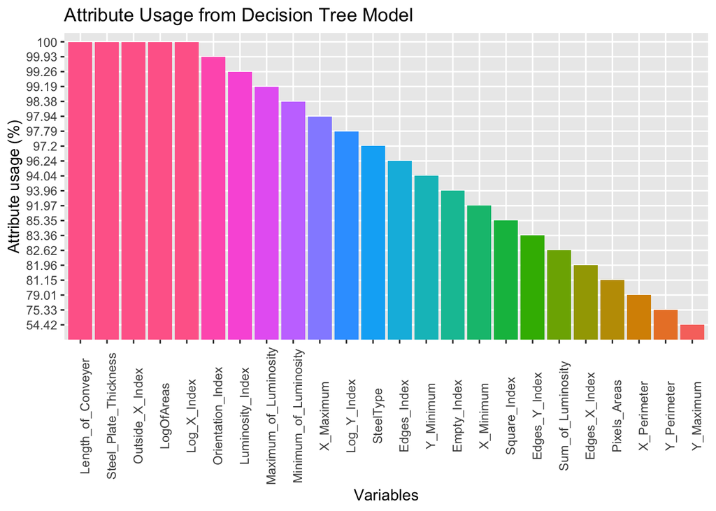

### VIII. Reference

[1] https://www.researchgate.net/publication/265124971_Steel_Plates_Faults_Diagnosis_with_Data_Mining_Models  
[2] https://www.worldsteel.org/steel-by-topic/steel-markets/buildings-and-infrastructure.html  
[3] https://tsapps.nist.gov/publication/get_pdf.cfm?pub_id=923309